# DO-MS Report

Version: 1.0.3 | Generated: 2019-02-20 15:48:44

## Summary

### MaxQuant Search Summary

MaxQuant Search Summary

MaxQuant Version: 1.6.0.16

Search Date: 04/01/2018 19:55:13

FASTA File: D:_human_09042017.fasta

### Experiment Map

Map of raw file names to short names

| Short name | Raw file | Folder | Path |
| --- | --- | --- | --- |
| 250ms IT | 180324S_QC_SQC68D1 | example_data_SQC68 | ~/Downloads/example_data_SQC68 |
| 500ms IT | 180324S_QC_SQC68D2 | example_data_SQC68 | ~/Downloads/example_data_SQC68 |
| 1000ms IT | 180324S_QC_SQC68D3 | example_data_SQC68 | ~/Downloads/example_data_SQC68 |

### MaxQuant Parameters

MaxQuant Search Parameters

|  | Parameter | example_data_SQC68 |
| --- | --- | --- |
| 1 | Folder Name | example_data_SQC68 |
| 2 | Folder Path | ~/Downloads/example_data_SQC68 |
| 3 | Version | 1.6.0.16 |
| 4 | User name | slavovlab |
| 5 | Machine name | DESKTOP-JODSSDS |
| 6 | Date of writing | 04/01/2018 19:55:13 |
| 7 | Fixed modifications |  |
| 8 | Include contaminants | True |
| 9 | PSM FDR | 1 |
| 10 | Protein FDR | 1 |

[output cut: 94 more lines]

### MaxQuant Experiment Summary

MaxQuant experiment summary statistics

|  | Raw.file | Raw.file.orig | Enzyme | Enzyme.mode | Enzyme.first.search | Enzyme.mode.first.search | Use.enzyme.first.search | Variable.modifications | Multi.modifications | Variable.modifications.first.search | Use.variable.modifications.first.search | Requantify | Multiplicity | Max..missed.cleavages | Labels0 | LC-MS.run.type | Time-dependent.recalibration | MS | MS.MS | MS3 | MS.MS.Submitted | MS.MS.Submitted..SIL. | MS.MS.Submitted..ISO. | MS.MS.Submitted..PEAK. | MS.MS.Identified | MS.MS.Identified..SIL. | MS.MS.Identified..ISO. | MS.MS.Identified..PEAK. | MS.MS.Identified..%. | … |
| --- | --- | --- | --- | --- | --- | --- | --- | --- | --- | --- | --- | --- | --- | --- | --- | --- | --- | --- | --- | --- | --- | --- | --- | --- | --- | --- | --- | --- | --- | --- |
| 1 | 250ms IT | 180324S_QC_SQC68D1 | Trypsin/P | Specific |  |  | False | Acetyl (Protein N-term);Oxidation (M) |  |  | False | False | 1 | 2 |  | Reporter ion MS2 |  | 10396 | 4534 | 0 | 4770 | 4298 | 0 | 472 | 3700 | 3532 | 0 | 168 | 77.57 | … |
| 2 | 500ms IT | 180324S_QC_SQC68D2 | Trypsin/P | Specific |  |  | False | Acetyl (Protein N-term);Oxidation (M) |  |  | False | False | 1 | 2 |  | Reporter ion MS2 |  | 7004 | 4994 | 0 | 5343 | 4645 | 0 | 698 | 4097 | 3854 | 0 | 243 | 76.68 | … |
| 3 | 1000ms IT | 180324S_QC_SQC68D3 | Trypsin/P | Specific |  |  | False | Acetyl (Protein N-term);Oxidation (M) |  |  | False | False | 1 | 2 |  | Reporter ion MS2 |  | 4973 | 4235 | 0 | 4669 | 3801 | 0 | 868 | 3439 | 3132 | 0 | 307 | 73.66 | … |

## Chromatography

### Elution profile: FWHM

Plotting the distrution of elution profile widths at half the maximum intensity value for each peak.

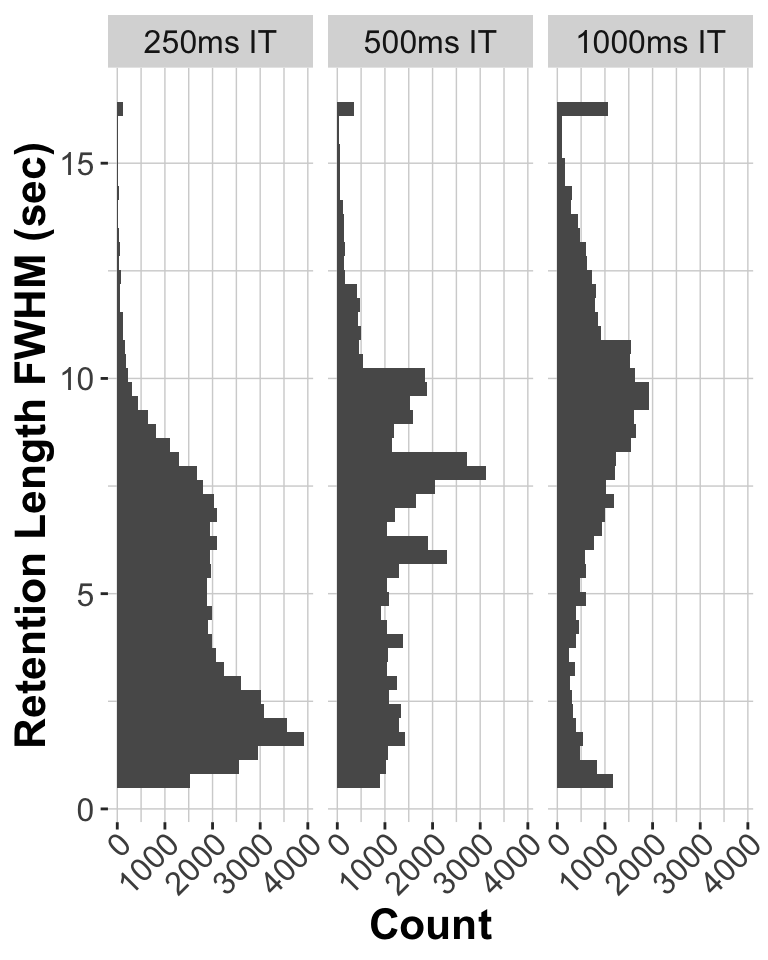

### Identification frequency across gradient

Plotting the frequency of peptide identification across the chromatographic gradient.

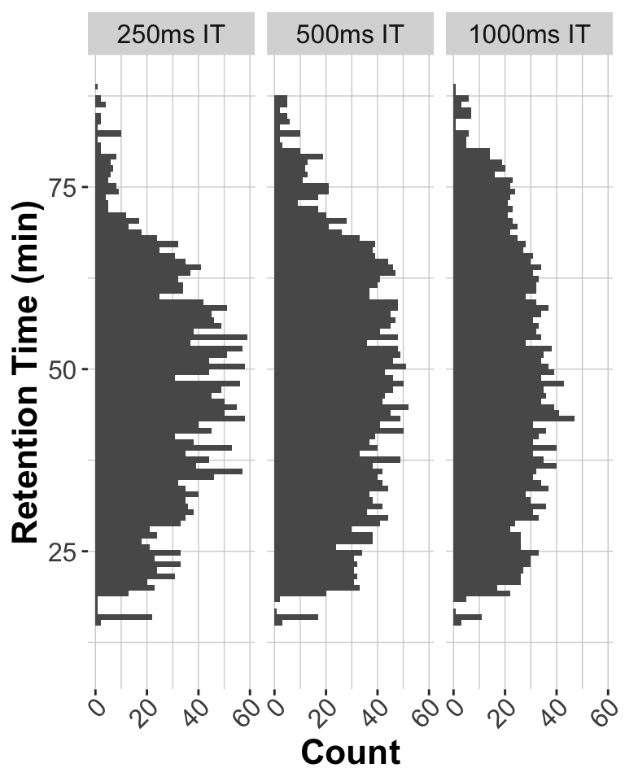

### Retention length of peptides at base

Plotting the retention length of identified peptide peaks at the base.

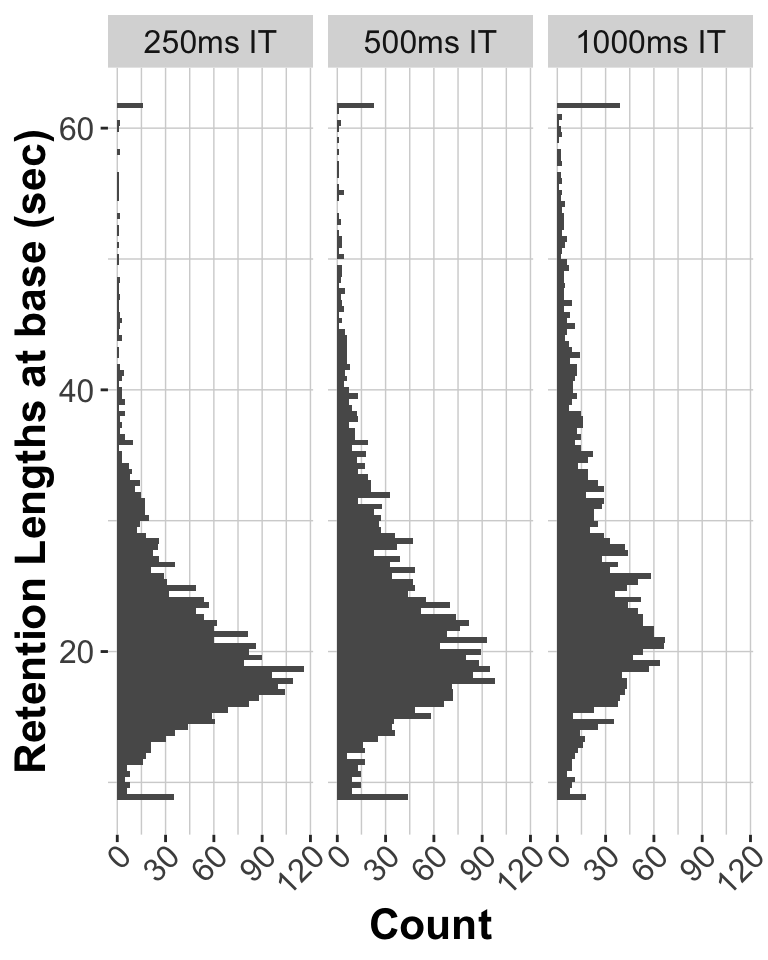

## Ion Sampling

### Apex Offset

Plotting the distance from the peak of the elution profile the MS2 events were executed.

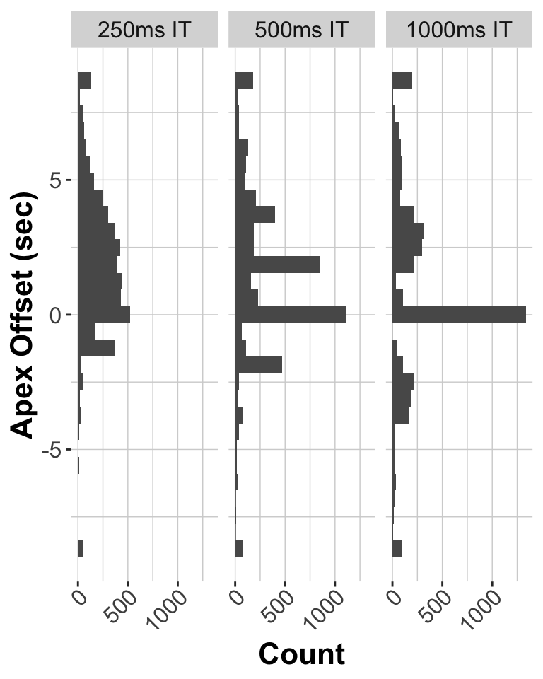

### MS1 Intensity for identified ions

Plotting the MS1 intensity for all identified ions across runs.

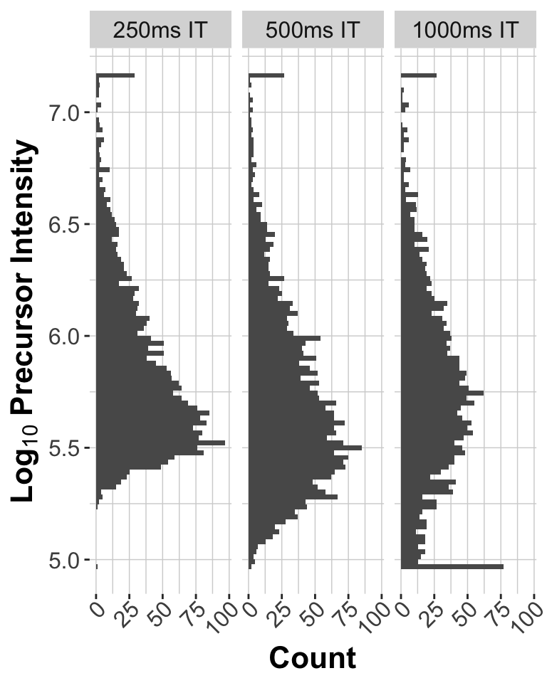

### MS1 Intensity for z>1 ions

Plotting the MS1 intensity for all peptide-like ions observed (not necessarily sent to MS2) across runs.

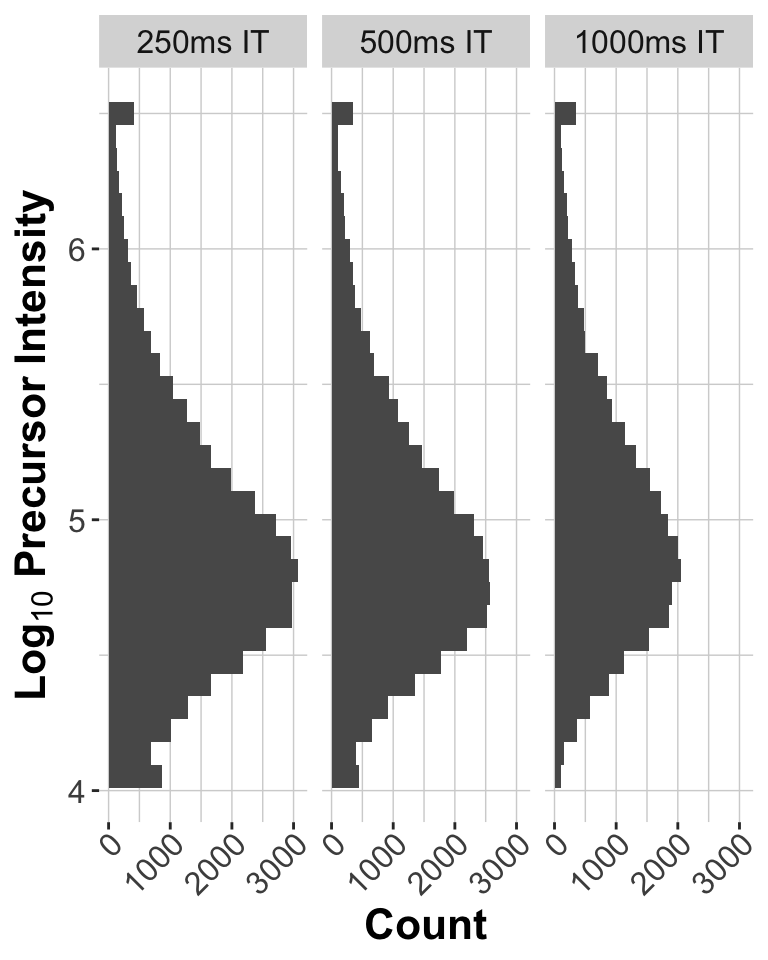

### MS1 Intensity for all ions

Plotting the MS1 intensity for all ions observed (not necessarily sent to MS2) across runs.

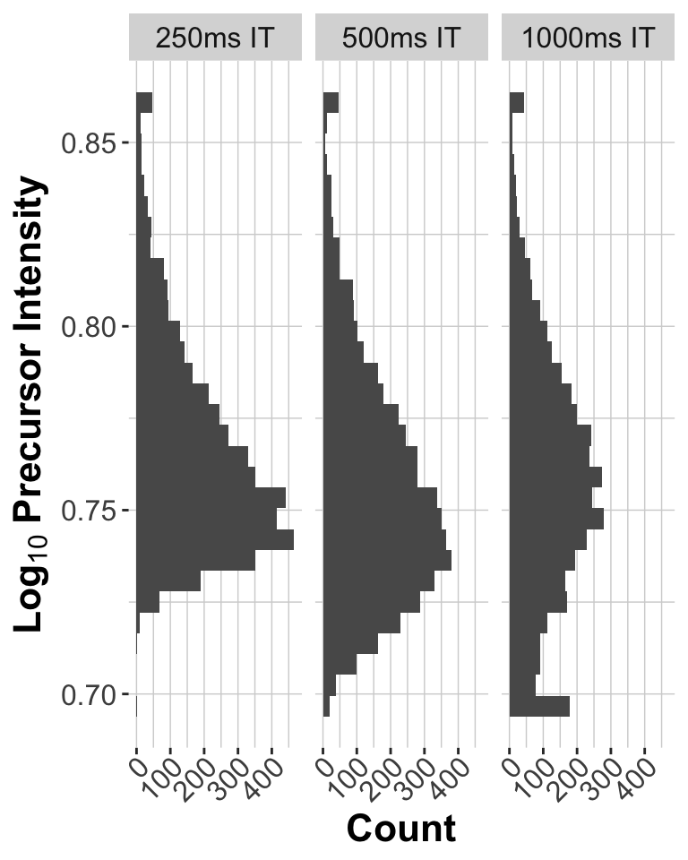

### Injection times, PSM resulting

Plotting distribution of injection times for MS2 events that did result in a PSM.

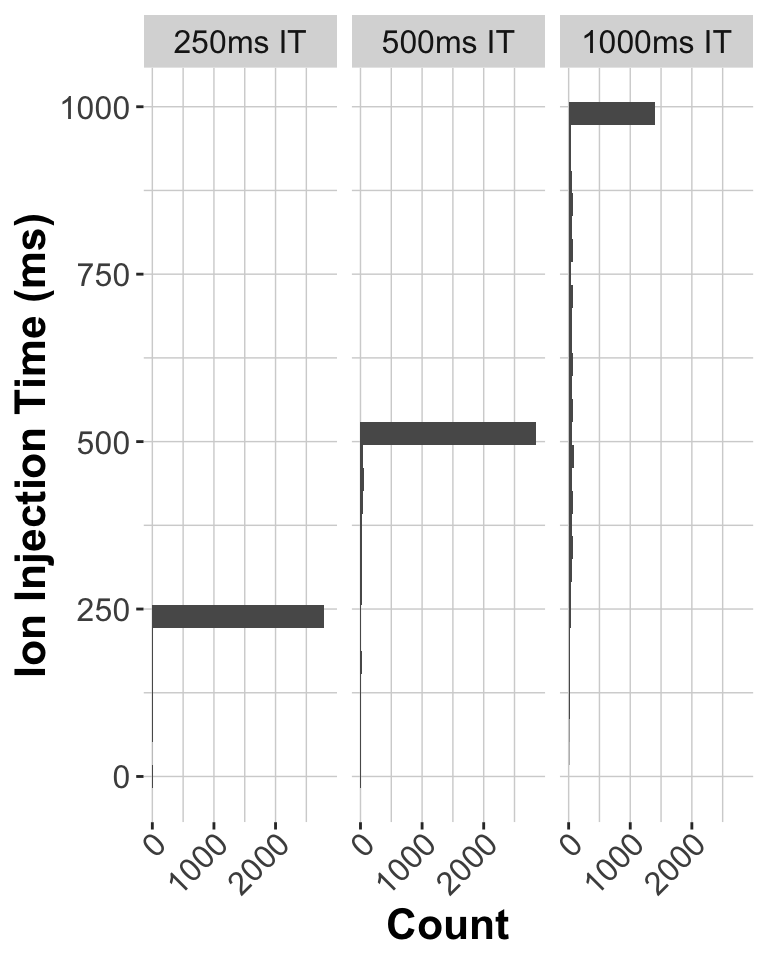

### Injection times, no PSM resulting

Plotting distribution of injection times for MS2 events that did not result in a PSM.

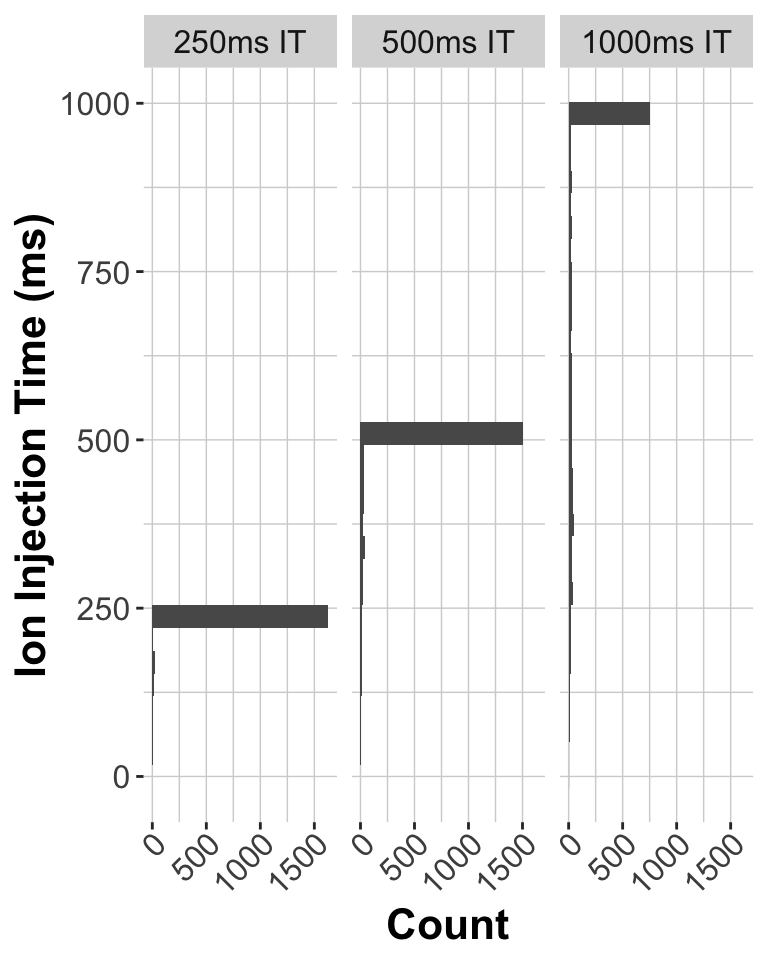

## Peptide Identifications

### Miscleavage rate

Plotting frequency of peptide miscleavages.

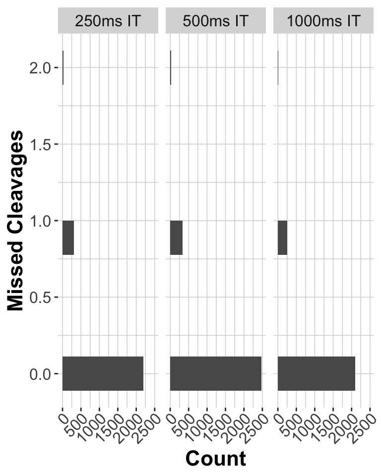

### Number of Confident Identifications

Plotting the number of peptides identified at each given confidence level.

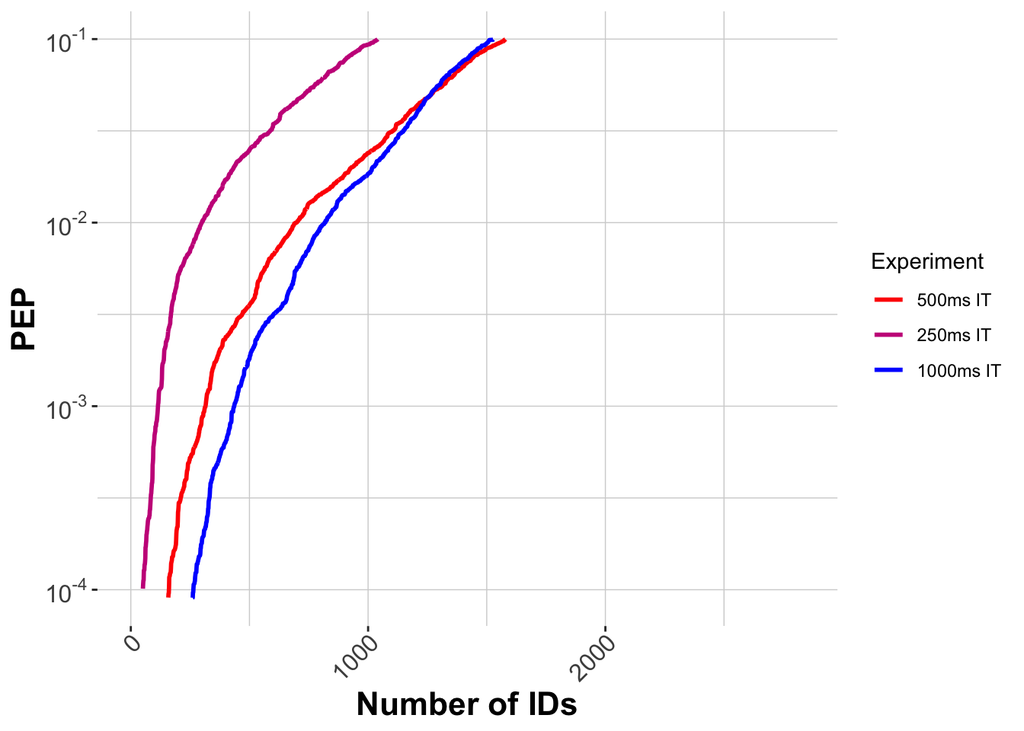

### Precursor Ion Fraction (PIF)

The distribution of PIFs for identified peptides across all sets, where PIF is a measure of coisolation (1 = pure, 0 = impure).

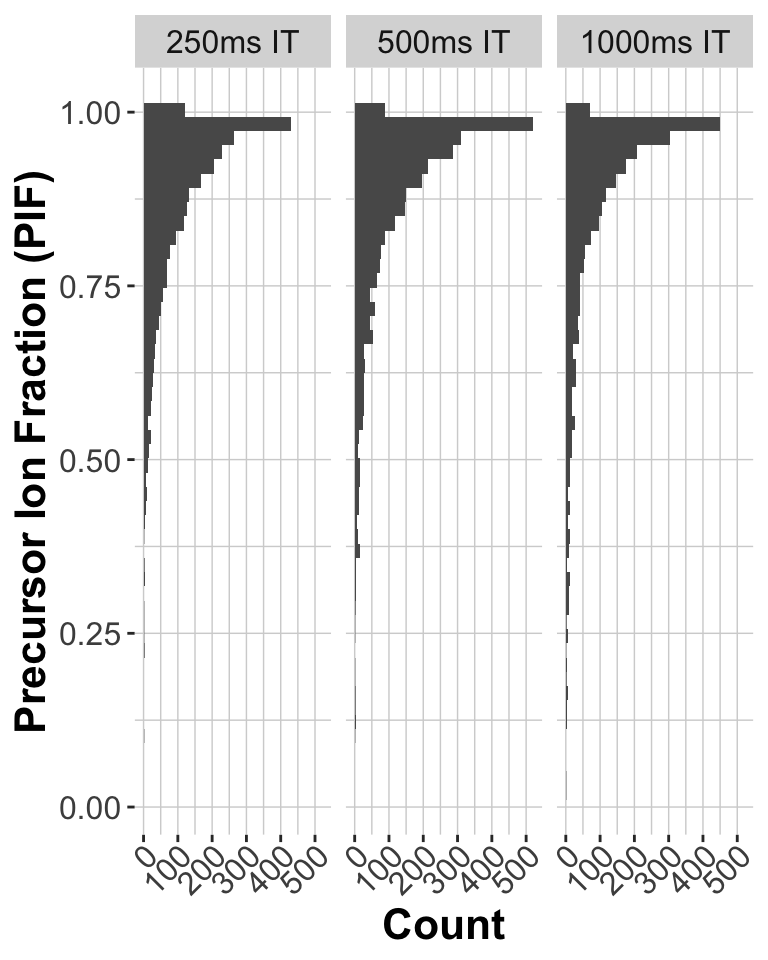

### Fractional ID Rate

Fractional rate of confident PSMs and PSMs from all MS2 scan events

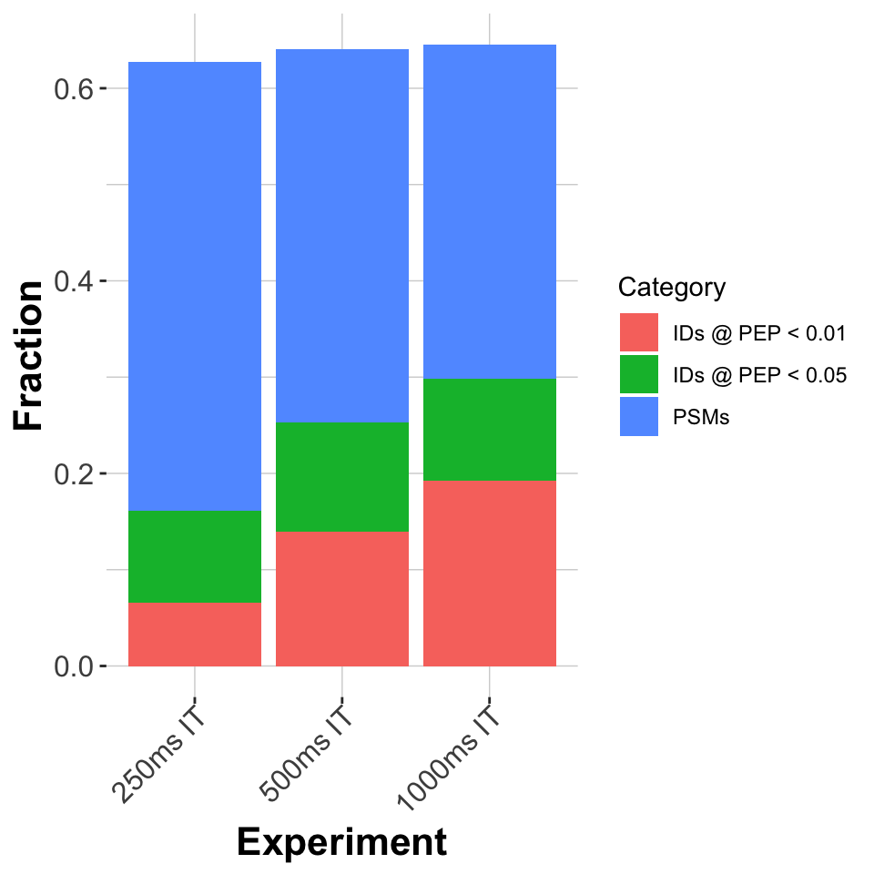

## Contamination

### Number of ions by charge state

Plotting the frequency of charge states observed. This will give an if you are seeing mostly peptides or non-peptide species

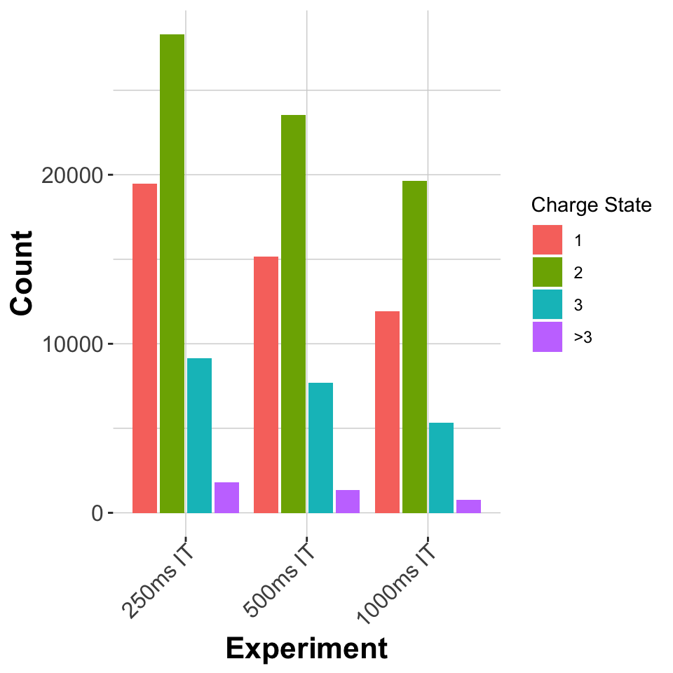

### TIC of ions by charge state

Plotting the TIC of charge states observed. This will give an idea if you are seeing mostly peptides or non-peptide species

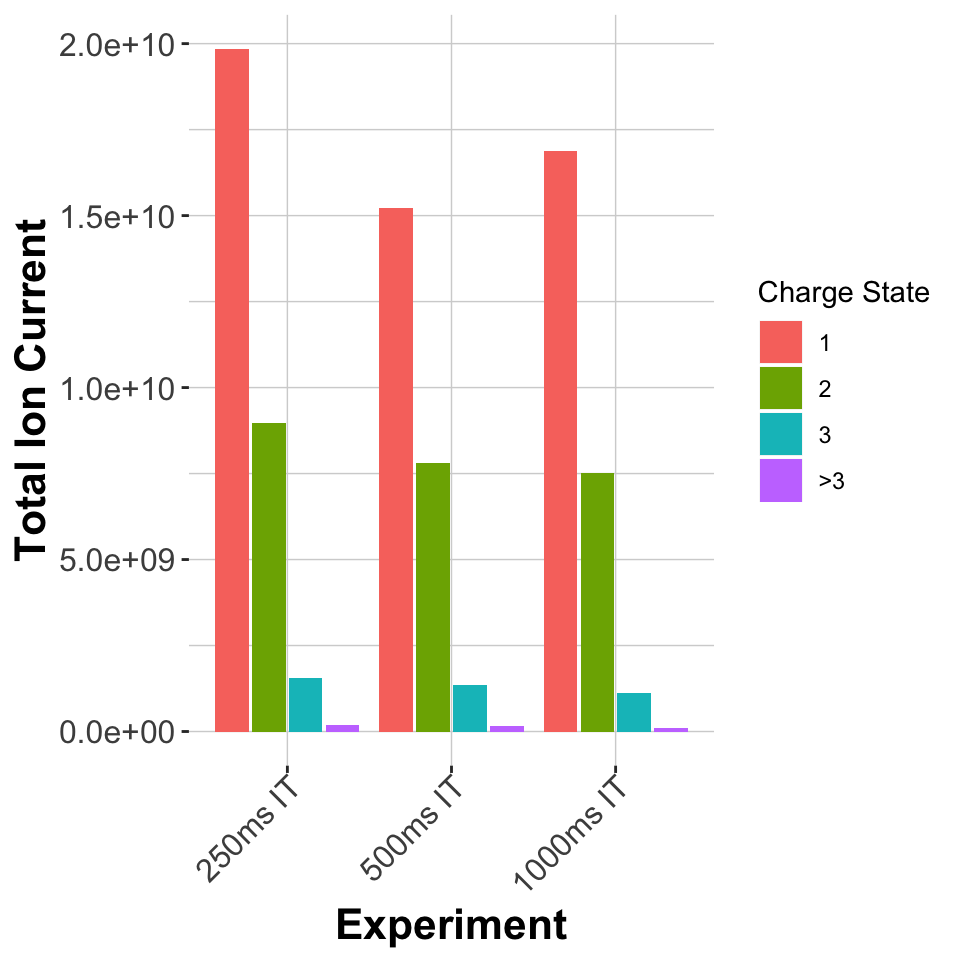

### MS1 Intensity, +1 ions

Plotting the intensity distribution of +1 ions, a diagnostic of non-peptide contaminants

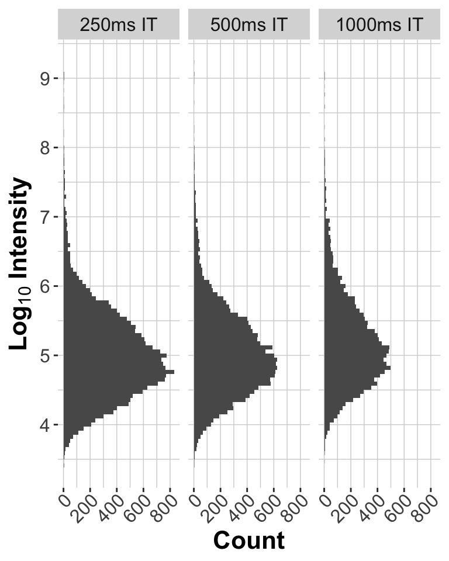

### m/z Distribution for +1 ions

Plotting the m/z distribution of +1 ions, a diagnostic of non-peptide contaminants

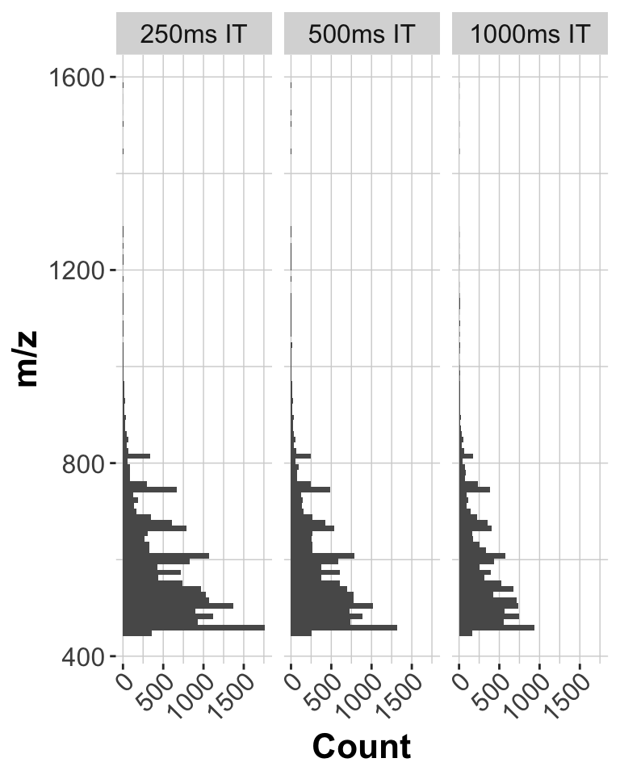

### Intensity of z=1 across gradient

Plotting the intensity of z=1 ions observed. This will give an if you are seeing mostly peptides or non-peptide species and where they occur in the gradient

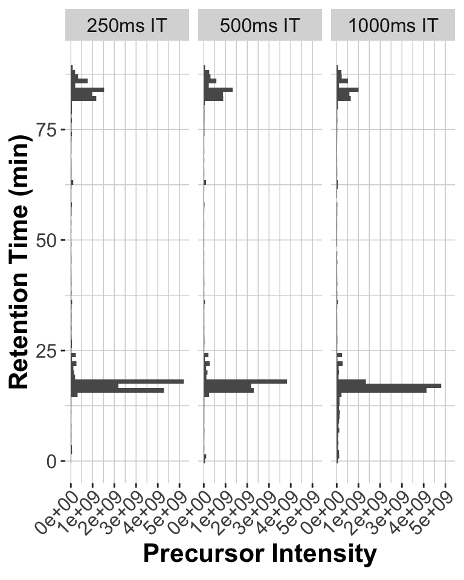

## SCoPE-MS Diagnostics

### Missing data per TMT channel

Calculating the missing values reporter per run per TMT channel, reported as 0 by MaxQuant.

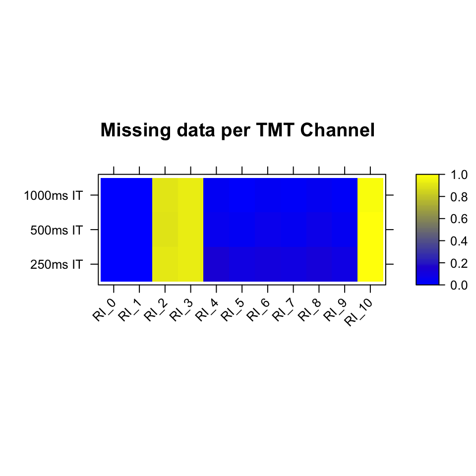

### TMT Channel Spearman Correlations vs. Intensity

Calculating the spearman correlation between the peptide quantitation in different TMT channels to the carry channel for every experiment, plotted against the median RI intensity for that channel.

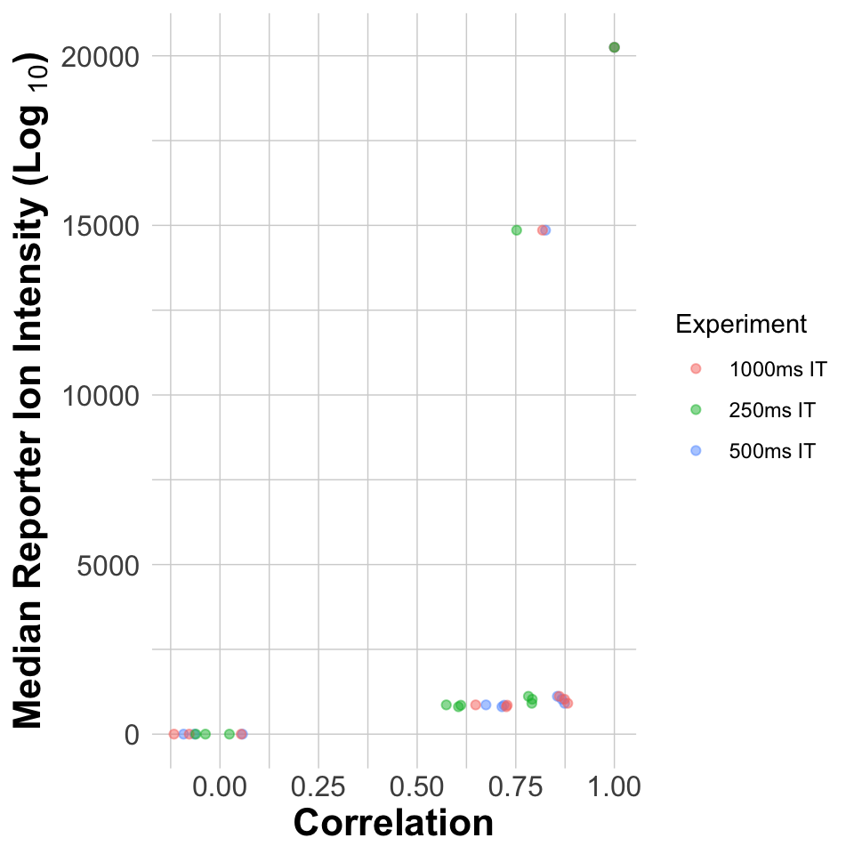

### Reporter Ion Intensities vs. Carrier Intensities

[output not shown]

### Reporter ion intensity

[output not shown]

### Relative reporter ion intensity

[output not shown]

## Targeting

### Inclusion List Evaluation

[output not shown]

## DART-ID

### Error Probability Update

[output not shown]

### Increase in Confident PSMs

[output not shown]

### RT Alignment Error

[output not shown]

### Peptide Identification Increase by Experiment

[output not shown]